# GRIN CHALLENGE

##### Daniel Urencio - *danielurencio@gmail.com*

## Propuestas de Expansión

Imagina que GRIN está por priorizar abrir operaciones en una ciudad nueva, por ejemplo Bogota vs Santiago o Sao Paolo vs CDMX. Debes determinar cuál ciudad priorizar de un para de ciudades candidatas, y determinar cuántos patines dejar. No cuentas con datos internos para tomar la decisión y debes estructurar un proyecto que abarque los siguientes puntos.

**1. ¿Qué datos externos utilizarías para tomar la decisión?**

La decisión de optar por una ciudad en vez de otra debe de tomar en consideración la conjunción de varios aspectos. Para poder proporcionar un diagnóstico claro, confiable y reproducible construiría un indicador global que se dotara a su vez de varios subindicadores.

En otras palabras, a través de ponderar númericamente ciertos aspectos que son favorables para el modelo de negocio de GRIN, construiría una calificación con base en los siguientes aspectos:

- **Aspectos demográficos** ($\mathbf{D}$): Se refiere a la concentración, por unidad espacial (metros cuadrados), de personas que pertenecen a cierto rango de edad (entre 15 y 35 años). A medida que en un determinado espacio exista un número mayor de personas aptas para manejar un scooter elétrico mayor es el número de clientes potenciales para la compañía.
- **Diversidad económica** ($\mathbf{E}$): Es la concentración de negocios y establecimientos por unidad espacial ponderada por cuán diversa es la zona analizada (la diversidad puede calcularse con métricas como la entropía de un conjunto de datos la cual puede interpretarse como una especie de varianza para datos discretos). Las zonas económicas que se caracterizan por ser densas y diversas no sólo se asocian con una mayor actividad económica sino con la predisposición de las personas a desplazarse de un lugar a otro.
- **Seguridad** ($\mathbf{S}$): Este indicador consideraría el número de delitos violentos por cada 100 mil habitantes así como el promedio mensual de accidentes automovilísticos.
- **Índices de marginación o rezago social** ($\mathbf{M}$): Existen ciertas convenciones para determinar qué tan desarrollada es una región urbana. Algunos ejemplos son la línea de bienestar o los índices de marginación urbana; este tipo de indicadores son, a su vez, una ponderación de varios aspectos sociales como nivel de escolaridad, acceso a servicios básicos y situación laboral.
- **Infraestractura en transporte alternativo** ($\mathbf{I}$): Una ciudad con una cantidad considerable en caminos como ciclovías y accesos peatonales puede generar mayores incentivos para que los usuarios de la aplicación utilicen los scooters recurrentemente. Este indicador puede construirse obteniendo la relación entre kilómetros cuadrados de espacios para el transporte alternativo y la superficie total de la ciudad analizada.

Una vez que se cuente con todos los datos para ambas ciudades puede procederse en el cálculo del $\mathbf{D}\mathbf{E}\mathbf{S}\mathbf{M}\mathbf{I}$ el cual consiste en generar una calificación global por ciudad construida a partir de la ponderación de los aspectos demográficos, económicos, de seguiridad, marginación e infraestructura.

$$ Calificación\ global = \mathbf{D} + \mathbf{E} + \mathbf{S} + \mathbf{M} + \mathbf{I} $$

La fuente de estos datos serían los censos económicos y demográficos que levantan las oficinas de estádistica de cada país, así como los repositorios de capas vectoriales para obtener las localizaciones de unidades económicas así como la extensión de las vías de comunicación (caminos y vías).

La búsqueda de datos consistiría en encontrar, en el país en cuestión, las equivalencias a instituciones como INEGI, CONAPO, y CONEVAL para así extraer, transformar y cargar la información en un esquema de bases de datos relacionales.

**2. Escribe un párrafo en el que expliques claramente al CEO:**

- La plataforma o lenguaje de programación que utilizarás para desarrollar un modelo que ayude a decidir qué zona de la ciudad tendrá más impacto.
- Cómo determinarás cuántos patines dejar en ciertas localizaciones y dónde deben estar esas localizaciones.

La metodología para determinar qué zona de la ciudad elegida tendrá mayor relevancia para el modelo de negocio de GRIN consiste en encontrar aquellos sitios en los que existe una mayor concetración de las condiciones que propician el uso de patines eléctricos. Para ello, se utilizará el Sistema de Información Geográfica de uso libre QGIS con el cual se creará un mapa que contendrá: la localización de establecimientos comerciales y zonas residenciales; los polígonos de incidencia delictiva y marginación urbana; así como los polígonos de zonas y vías para ciclistas y peatones. Aquellas áreas en las que se de la intersección de todos estos aspectos serán elegidas como zonas de alto impacto. Por último, se distribuirá un número de patines igual a la mitad de la población económicamente activa de cada zona; este número será distribuido equitativamente en las inmediaciones de cada parque y estación de transporte colectivo.

**3. ¿Cómo estructurarías un equipo de DATOS para terminar este proyecto lo antes posible?** Un equipo de tres personas podría manejar este proyecto en un tiempo considerable. Todos deberían de tener experiencia usando lenguajes de programación intérpretes (preferentemente Python) y manejando bases de datos en SQL.

Por lo menos uno de los integrantes debe de tener un conocimiento elevado en herramientas GIS y sistemas de coordenadas. Lo óptimo, en mi experiencia, es que todos tengan cierto grado de involucramiento en la totalidad del proyecto pero que cada miembro se especialice en diferentes tareas según su dominio y experiencia.

En este sentido, todos los miembros del equipo deberían de conocer cómo están estrucutradas las bases de datos pero alguien en particular las administra. Asimismo, todos deberían de contribuir generando contenidos para la publicación del entregable final pero alguien es el responsable del control de versiones.

Trabajar de esta manera permite que nadie sea absolutamente indispensable en caso de ausentarse; y, a la vez, fomenta la productividad, pues quien conoce mejor de cierto tema es quien tiene la oportunidad de profundizar más en él.

Los roles o habilidades que, en términos generales, consideraría para este proyecto son:

- DBA / web scraper
- Visualizador de datos / cartógrafo
- API coder / back end developer
- Coder / statistician

**4. Describe las fases en las que estructurarías los tiempos del proyecto y la duración de cada fase.**

- **Identificación de necesidades y fuentes de información (4-5 días)**: En principio, es necesario hacer un recuento de qué es lo que se va a medir y de qué lugar se obtendrán los insumos. Esto implica asegurarse de que la información que se vaya a obtener permita, a través de la construcción de indicadores, hacer comparaciones fidedignas entre ciudades. Asimismo, esta fase también involucra trabajar en el planteamiento metodológico que va a utilizarse para el diagnóstico; si bien, éste puede definirse desde un inicio, también puede someterse a cambios a lo largo de futuras etapas.
- **Automatización de la extracción y carga para asegurar la reproducción de procesos (4-6 días)**: Al haber acotado qué variables e indicadores tendrán que construirse, además de haber identificado la fuente de donde se obtendrán los datos en su forma más cruda, esta etapa comprende definir el proceso, las herramientas y los lenguajes que se utilizarán para automatizar la extracción de datos. Del mismo modo, se empezaría con la creación de bases de datos y tablas relacionales que podrán empezar a ser pobladas conforme se progrese en el proceso de extracción.
- **Evaluación de resultados hasta el momento y QA (4-5 días)**: En esta fase se revalúan las necesidades de información con base en la disponibilidad de datos, esto se hace para poder garantizar la comparación exhaustiva entre ciudades. Si hay aspectos que necesitan reajustarse tanto en la identificación de necesidades de información como en la automatización de la extracción y carga, éste es el momento en el que ello debe de hacerse. A la par, es posible empezar a programar un proceso que garantice que la extracción y carga se están efectuando con los estándares de calidad necesarios para que el diagnóstico pueda llevar a cabo satisfactoriamente.
- **Desarrollo de interfaz para análisis exploratorio (7-10 días)**: Esta parte del proceso puede ponerse en marcha desde el inicio del proyecto y desarrollarse paralelamente con otras tareas. Sin embargo, esto no podrá ser completamente funcional hasta que el flujo de extracción, carga y QA estén completamente definidos. Desarrollar un tablero/dashboard permite no sólo visualizar y rastrear los avances en términos de las necesidades de información, sino que también puede ser un producto muy útil para presentar y documentar el diagnóstico a otros equipos dentro de la empresa.

  No es necesario hacer un desarrollo completo en términos de *front end*, para este desarrollo podrían utilizarse herramientas de uso libre como [Jupyter](https://jupyter.org/), [Dash](https://plot.ly/products/dash/) o [Bokeh](https://bokeh.pydata.org/en/latest/). A la par, se debe de trabajar en las conexiones a las bases de datos o alguna especie de API que alimente de datos al tablero.
- **Cálculo de indicadores, revaluación y presentación de resultados (3-4 días)**: Hasta este punto se debe de contar con un flujo completamente funcional de información en términos de consultas a bases de datos y visualización interactiva a través de un tablero. Esta etapa puede involucrar algunos cambios como la manera en la que se exponen los resultados, pero el cálculo de indicadores para realizar el diagnóstico comparativo entre ciudades debería de ocurrir en automático independientemente de cualquier modificación.

**5. ¿Cómo describirías el entregable final?**

Tal y como se comentó en el punto anterior, el entregable sería una document/tablero interactivo que permitiría obtener los hallazgos del diagnóstico de manera directa e intuitiva. Asimismo, presentar el entregable final de esta manera es una forma de documentar no sólo la metodología del proyecto sino la forma en la que éste se automatizó.

## Código de operación de *Patines en Calles*

Imagina que tienes 2 tablas en una base de datos:

La tabla ride contiene la siguiente información acerca de los rides:

```
● id id del viaje (int)
● scooter_id id del scooter (int)
● user_id id del usuario (int)
● started_at hora de comienzo del viaje (timestamp)
● finished_at hora de final del viaje (timestamp)
● location_start localización de inicio del viaje (lat, long)
● location_end localización de final del viaje (lat, long)
```

La tabla scooter_event contiene la siguiente información de los eventos del status de los patines:

```
● id id del evento (int)
● scooter_id id del scooter (int)
● created_at fecha y hora de creación (timestamp)
● user_id id del usuario que creó el evento (int)
● status status del patín (cargando, en calle, en reparación) (string)
```

Escribe un query/código en el lenguaje de tu preferencia que cree una tabla que muestre el número de patines en calles que NO se utilizaron durante cada día de operación.

```
with scooter_info as (
    select
        A.*,
        B.rider_id
    from (
      select date_trunc('day',created_at) as date,scooter_id as date from scooter_events
    ) A
    left join ( select date_trunc('day',create_at), user_id as rider_id as date from rides ) B
    on
      A.date = B.date
     and
      A.scooter_id = B.scooter_id
)
select * from (
    select
        date,
        count(distinct scooter_id) as used_scooters
    from scooter_info
    group by date
)
where used_scooters = 0;
```

## Test de distribución de patines

En GRIN muchas veces queremos probar si un cambio en la distribución de patines (locales donde dejamos los patines por la mañana) en el mapa tiene mejor tasa de conversión, es decir, que nuestros usuarios los utilizen.

Hemos decidido plantear el problema como una prueba de hipótesis donde

- $H_{0}$: la proporción de patines que se usan con el cambio de distribución es igual a la proporción de patines que se usan sin el cambio de distribución
- $H_{1}$: la proporción de patines que se usan con el cambio de distribución es mayor.

Al realizar el experimento, obtienes un **p-value** de **0.032** con un nivel de significancia del **0.01** para la diferencia de proporciones y un intervalo de confianza del **99%** de la forma **(-0.005, 0.005)**.

**¿Cómo interpretarías los resultados del experimento y qué recomendaciones harías al equipo de distribución?**

A un nivel de significancia del 1%, el experimento señala que no existen elementos suficientes para rechazar la hipótesis nula, puesto que para una prueba de dos colas vemos que $p\_value > 0.005$.

Si el $p\_value$ hubiese sido menor al nivel de significancia establecido *a priori*, tendríamos más elementos para rechazar la hipótesis nula y considerar que una mayor proporción de patines usados pudo haber resultado como consecuencia del cambio en la distribución.

La recomendación para el equipo, según los resultados del experimento, sería no favorecer la nueva distribución pues no tenemos elementos contundentes para garantizar que esta logística resultará en una proporción mayor de patines usados.

## *Brain teaser* de probabilidad inferencial

Sean $X$ e $Y$ dos variables aleatorias. Si $\mathbf{E}[X] = 75$, $\mathbf{E}[Y] = 75$, $\mathbf{Var}[X] = 10$, $\mathbf{Var}[Y] = 10$ y $\mathbf{Cov}[X,Y] = -3$.

Encuentra una cota superior (*upper bound*) para $\mathbf{P}(|X-Y| > 15)$.

Dado que $X$ e $Y$ son dos variables aleatorias dependientes $\big(\mathbf{Cov}[X,Y] \neq 0\big)$, podemos obtener las siguientes ecuaciones,

$$ \begin{aligned} \mathbf{E}[X-Y] &= \mathbf{E}[X] - \mathbf{E}[Y] \end{aligned} $$

$$ \begin{aligned} \mathbf{Var}[X] &= \mathbf{E}\Big[ \big( X - \mathbf{E}[X] \big)^{2} \Big]\\ &= \mathbf{E}\Big[ x^2 - 2X\mathbf{E}[X] + \mathbf{E}[X]^2 \Big] \\ &= \mathbf{E}[X^2] - 2 \mathbf{E}[X]^2 + \mathbf{E}[X]^2 \\ &= \mathbf{E}[X^{2}] - \mathbf{E}[X]^2 \end{aligned} $$

$$ \begin{align} \mathbf{Cov}[X,Y] &= \mathbf{E}\Big[ \big(X - \mathbf{E}[X]\big) \big( Y - \mathbf{E}[Y] \big) \Big] \\ &= \mathbf{E}\Big[ XY - X\mathbf{E}[Y] - Y\mathbf{E}[X] +\mathbf{E}[X]\mathbf{E}[Y] \Big] \\ &= \mathbf{E}[XY] - \mathbf{E}[X]\mathbf{E}[Y] - \mathbf{E}[X]\mathbf{E}[Y] + \mathbf{E}[X]\mathbf{E}[Y]\\ &= \mathbf{E}[XY] - \mathbf{E}[X]\mathbf{E}[Y] \end{align} $$
y, por lo tanto, si tomamos $X-Y$ como si fuera una variable aleatorioa tenemos lo siguiente,

$$ \begin{aligned} \mathbf{Var}[X-Y] &= \mathbf{E}\Bigg[\Big((X-Y) - \mathbf{E}[X-Y]\Big)^{2}\Bigg] \\ &=\mathbf{E}\big[(X-Y)^2\big] - \mathbf{E}\big[ X-Y \big]^{2}\\ &=\mathbf{E}[X^2] - 2\mathbf{E}[XY] + \mathbf{E}[Y^2] - \Big( \mathbf{E}[X] - \mathbf{E}[Y] \Big)^{2} \\ &=\mathbf{E}[X^2] - 2\mathbf{E}[XY] + \mathbf{E}[Y^2] - \mathbf{E}[X]^{2} + 2\mathbf{E}[X]\mathbf{E}[Y] - \mathbf{E}[Y]^{2} \\ \\ & reordenando\ términos\\ &= \Big( \mathbf{E}[X^2] - \mathbf{E}[X]^2 \Big) + \Big( \mathbf{E}[Y^2] - \mathbf{E}[Y]^2 \Big) - 2\Big( \mathbf{E}[XY] - \mathbf{E}[X]\mathbf{E}[Y] \Big) \\ &= \mathbf{Var}[X] + \mathbf{Var}[Y] - 2\mathbf{Cov}[X,Y] \end{aligned} $$

ahora; la desigualdad de Chebyshev nos dice que,

$$ \mathbf{P}(|\mathbf{X} - \mu | \geq k) \leq \frac{\sigma^2}{k^2} $$

si,

$$ \begin{align} \mathbf{E}[X-Y] &= \mathbf{E}[X] - \mathbf{E}[Y]\\ &= 75 - 75\\ &= 0 \end{align} $$
$$ \begin{align} \mathbf{Var}[X] + \mathbf{Var}[Y] - 2\mathbf{Cov}[X,Y] &= 10 + 10 -2(-3) \\ &= 26 \end{align} $$

$$ \begin{align} k = 15 \iff k^2 = 225 \end{align} $$

entonces,

$$ \mathbf{P}(|X-Y| > 15) \leq 0.116 $$

# Final Project

## Data exploration

#### Tools and libraries

The following project will use Python 3 as its main programming language. Along with Python, a few libraries will be imported; the comments in the following block of code illustrate what they are used for.

```
# Tablular data handling
import pandas as pd

# Database connection credentials
import credentials as c

# useful for handling matrices and vectors
import numpy as np

# Database connection driver
from sqlalchemy import create_engine

# Machine Learning library
from sklearn.cluster import KMeans

# Miscellaneous
import os
import math
import json
```

### A) Connect to the database using your favorite programming tool

```
# Connection string
conn_str = 'postgresql://' + c.usr + ':' + c.psw + '@' + c.host + '/' + c.db

# Create connection
conn = create_engine(conn_str)

# Query all available tables
tables = \
'''
    SELECT
        schemaname,
        tablename,
        tableowner
    FROM pg_catalog.pg_tables
    where
        schemaname not in ('pg_catalog','information_schema')
'''

# Fetch the information
tables = pd.read_sql(tables,conn)
```

By calling the `tables` variable we can see the available tables from the credentials we were provided.

```python
tables
```

|  | schemaname | tablename | tableowner |
| --- | --- | --- | --- |
| 0 | public | open_app_1 | grin_technical_challenge |
| 1 | public | rides | joao |
| 2 | public | open_app | joao |

### B) Tell more about the data structure; describe in a less than 50 words what each table is measuring

- `rides`: This table contains specific information about each ride such as time, duration, location, as well as who used what scooter.
- `open_app`: It contains information regarding who opened the app and where.

Both tables can be joined by the `open_app_id` and `id`.

##### Data munging

The following lines will fetch all the records from the available tables. As it can be noticed, there is a conditional statement that allows for a more efficient way to handle with the data.

In other words, hitting the server for all records of each table might take some time, hence we export the information to a `csv` file after we have done some wrangling. If the `csv` file already exists we no longer need to query the server, we only need to import the file which ends up in a much shorter period.

```
saved = list(filter(lambda x:x == 'open_rides.csv' ,os.listdir()))
saved = len(saved)

if not saved:
    # Store all table names inside a list
    tablenames = tables.tablename.tolist()

    # Query all records from all available tables
    query = 'select * from '
    table_dict = { table:pd.read_sql(query + table,conn) for table in tablenames }

    # Rename repeated columns
    table_dict['rides'].rename(columns={
                                'id':'ride_id',
                                'user_id':'ride_user_id'
                               },inplace=True)

    table_dict['open_app'].rename(columns={
                                    'starting_lng':'app_starting_lng',
                                    'starting_lat':'app_starting_lat'
                                  }, inplace=True)

    # Merge all tables into a single one
    open_rides = pd.merge(
                    table_dict['open_app'],
                    table_dict['rides'],
                    how='left',
                    left_on='id',
                    right_on='open_app_id'
    )

    # Export data into a csv to avoid clogging the memory
    open_rides.to_csv('open_rides.csv',index=False)

    # Release memory
    del table_dict

else:
    # If a csv has already been generated open it
    open_rides = pd.read_csv('open_rides.csv',parse_dates=['open_time','start_time','finish_time'])
```

After transforming the data we end up with a table with all records from the `open_app` table. Furthermore, for those times were opening an app involved a ride, all the information related to that ride is also included in this single table.

The first three rows of the table look as follows:

```
open_rides.head(3)
```

```python
open_rides.head(3)
```

|  | id | open_time | app_starting_lng | app_starting_lat | user_id | ride_id | open_app_id | start_time | finish_time | starting_lng | starting_lat | dest_lng | dest_lat | price | ride_user_id | scooter_id |
| --- | --- | --- | --- | --- | --- | --- | --- | --- | --- | --- | --- | --- | --- | --- | --- | --- |
| 0 | 4955617 | 2018-09-02 00:43:47.421261 | -46.510508 | -23.586433 | 418876.0 | NaN | NaN | NaT | NaT | NaN | NaN | NaN | NaN | NaN | NaN | NaN |
| 1 | 5060590 | 2018-09-02 10:47:46.494678 | -46.651740 | -23.520904 | 907110.0 | NaN | NaN | NaT | NaT | NaN | NaN | NaN | NaN | NaN | NaN | NaN |
| 2 | 5134523 | 2018-09-03 01:50:26.777903 | -46.651894 | -23.538765 | 257336.0 | NaN | NaN | NaT | NaT | NaN | NaN | NaN | NaN | NaN | NaN | NaN |

### C) What is the % of open apps that had a ride per day? What does metric mean for the company?

In order to answer these questions, we will add two more columns to our table. We will truncate the `open_time` by day and name this feature `date`, this will allow us to group the data by day. Additionally, we will add a boolean value for those times that a user opened the app and either had a ride or not; a value of `1` represents a ride whereas a `0` means there was no ride.

```
open_rides['date'] = open_rides.open_time.dt.date
open_rides['was_ride'] = open_rides['start_time'].map(lambda x: 1 if not pd.isnull(x) else 0)
open_rides.sort_values('date',inplace=True)
```

Now that we have these additional pieces of information, we can group the data by day and count both the unique number of rides and the unique number of times that the app was opened by the user.

If we now want to look at the proportion of app openings that involved a ride per day, we can then average our daily boolean values (`was_ride` column). Given that, for any given date, we have a total number of app openings for which all or some could have ended up in a ride; an average of all our `0` and `1` values per day will give us what we want.

```
daily_ride_average = open_rides[['date','was_ride']].groupby('date',as_index=True).mean()
```

If we plot this:

```
daily_ride_average.sort_values('date').plot(figsize=(15,10));
```

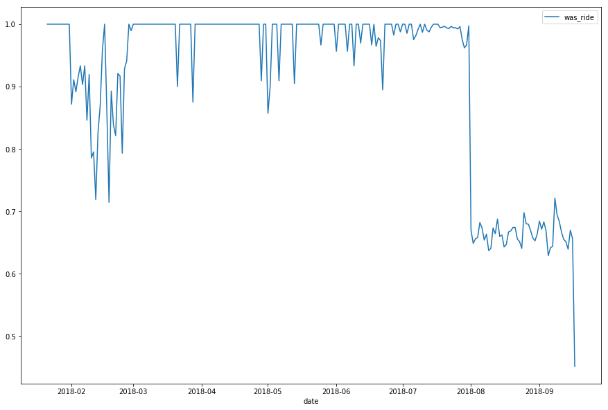

```python
daily_ride_average.sort_values('date').plot(figsize=(15,10));
```

After having a daily average of app openings that ended up in a ride, if we want to have a single figure for the average percentage of open apps that turned into a ride we can then average all daily averages.

```
daily_ride_average.was_ride.mean()
```

```python
daily_ride_average.was_ride.mean()
```

```
0.9116776341236884
```

This means that, on average, the company has been able to meet 91% of the estimated demand if we interpret the number of app openings as a proxy for the users' willingness to ride a scooter. However, it might be more useful to look at this figure from a time-series perspective such as what the plot from above depicts.

### D) What is the missing piece of data (or table) that we would require to calculate or find the Balance of the supply/demand equation:

$$ Balance = + Supply − Demand $$

Although we can see the number of used scooters as well as who used them, both `rides` and `open_apps` do not contain information regarding the number of functioning scooters that the company is supplying. In order to have a full account of what is the total supply, we require a list of scooter ids that are functional and that have been logistically distributed in a given city.

## Solving the problem

##### The problem is that we have no idea where to place scooters according to the user demand. Using the database above please create a model that can generate an output with a strong insight that can tell us where to place scooters.

### MODEL SUGGESTION: Adjustable K-means through Time

##### INPUT: Space should not be independent of time

In this problem, what we want is to output a suggestion for locations based on what the company perceives from the demand side. At its rawest presentation, a location could be a pair of coordinates, therefore, a desirable output could be a set of latitude-longitude pairs.

However, any kind of input could deliver such list of pairs. We could take the whole history of unmet demand and from that generate a mere list of sites. In that case, there would hardly be any context from such output given that customer preferences could change, people might frequent different places, and weather conditions could put users off taking a scooter ride.

For these reasons, this model proposes a time-oriented solution that captures the most recent user behavior based on taking as the model's input a proxy for the unmet demand of the last **n** days. Concretely, the model's input should be obtained by concatenating all coordinates from the last **n** days containing app openings that did not end up as a ride. Using this approach should enable planning each day's scooter distribution agenda by merely fetching the latest unmet demand information.

##### OUTPUT: Dimensionality reduction without abuse

Meeting demand does not necessarily require placing a scooter on every spot where a user has opened the app, that would be a greedy and inefficient approach. Certainly, scooters could be placed in locations where users have recently looked for a ride; having to walk a couple of minutes is quite different from not spotting any scooters whatsoever.

As a method to output a list of suggested locations for scooters to be distributed, a generalization of relevant spots could be useful. This could be achieved by using some sort of clustering algorithm, hence an extension of K-means clustering is proposed for this task.

##### INPUT-TO-OUTPUT MIDDLEWARE: A K-means extension

K-means, in short, is an algorithm that:

1. Is initialized by choosing a fixed number of centroids which are then randomly initialized in an n-dimensional space.
2. Every observation $i$ within a dataset should be assigned to a cluster $k$ based on a shortest distance metric such as $||x_{i}-\mu_{k}||^2$.
3. Once every observation has been assigned to a centroid/cluster, the position of each centroid is recalculated by averaging all of its members.
4. Repeat 2 and 3 until convergence.

[figure not shown]

One problem with this algorithm is that the number of clusters must be specified beforehand. For large datasets, such as the one contained in the `open_app` table, K-means can be computationally expensive especially if a large number of clusters are to be chosen. On the other hand, if only a few clusters are defined then we are trading efficiency in computation for efficiency in meeting demand.

The proposed approach for this is to extend K-means by generating clusters recursively as well as choosing the number of clusters $K$ with a log transformation of the number of observations in each recursion step. By generating clusters recursively we mean that after an initial set of clusters has been defined subclusters will be generated for each initial cluster and this process will be repeated until there are no more subclusters left to assign. This is possible given that, at each recursion step, the number of clusters/subclusters $K$ is defined as $K = \log(n)$ where $n$ corresponds to the number of observations in each cluster/subcluster.

As recursion steps develop and new subclusters are generated $n$ declines and so does $\log(n)$, hence this process is guaranted to reach a point where $K=1$ and there are no more clusters to which observations can be adhered to. Additionally, computing $\log(n)$ keeps the number of clusters relatively low. This promotes speed while fitting K-means on every recursion step.

[figure not shown]

##### Pseudo-code:

```
Initialize input (input = coordinates of last n days open apps without ride)
Define n as the number of observations within the input
Define K as log(n)
Run K-means for the whole input with k=log(n)

For i in K:
    Initialize the new input by fetching all observations assigned to cluster K_i
    Define n as the number of observations in input
    Define K as log(n)
    Run K-means for the new input with K=log(n)

    For j in K:
        ...
        ...
        ...
        Run K-means for the new input with K=log(n)

        For k in K:
            ...
            ...
            ...

        Stop when K == 1
```

### Model API

A good way to exemplify how this model could be instantiated and used is through wrapping the whole logic inside an Object-Oriented class. The object `findSpots` has several methods that allow the implementation of all the steps from the proposed model above.

```
class findSpots():

    def __init__(self,data,lag):
        self.data = data
        self.lag = lag


    def moving_dates(self):
        unique_dates = self.data[self.data.was_ride == 0].date.unique()
        moving_dates = [ unique_dates[i:i+self.lag] for i,d in enumerate(unique_dates) ]
        moving_dates = list(filter(lambda x: len(x) == self.lag, moving_dates))

        return moving_dates


    def recursiveSites(self,df):
        df = df.copy()
        coordinates = df[['app_starting_lat','app_starting_lng']]
        x = coordinates.values
        n_records = len(coordinates)
        n_clusters = math.floor(np.log(n_records)) if n_records > 0 else 1
        n_clusters = n_clusters if n_clusters > 0 else 1

        if n_records < 3:
            coordinates = coordinates.append(coordinates)

        kmeans = KMeans(n_clusters=n_clusters).fit(x)

        df['k_labels'] = kmeans.labels_
        centers = kmeans.cluster_centers_

        return (df,centers)


    def originToIterateWith(self,period):
        filter_ = (self.data.date.isin(period)) & (self.data.was_ride == 0)
        data = self.data[filter_]

        return self.recursiveSites(data)


    def removeDuplicatedSites(self,sites):
        arr = []

        for i in sites:
            arr += i.tolist()

        arr = list(set(map(lambda x:str(x),arr)))
        arr = list(map(lambda x:json.loads(x),arr))

        return arr


    def returnSites(self,period):
        print('Please wait. A site list is being generated, this might take a while.')
        origin = self.originToIterateWith(period)
        self.siteContainer = []

        def recursiveClusters(df):

            labels = df.k_labels.unique()

            for i in range(len(labels)):

                df_ = df[df.k_labels == i].copy()
                rec = self.recursiveSites(df_)
                new_labels = len(rec[0].k_labels.unique())

                if new_labels == 1:
                    self.siteContainer.append(rec[1])
                    return

                else:
                    recursiveClusters(rec[0])

        recursiveClusters(origin[0])
        siteList = self.removeDuplicatedSites(self.siteContainer)
        print(str(len(siteList)) + ' sites were found!')

        return siteList


    def plotSites(self,period,siteList=False):
        open_rides = self.originToIterateWith(period)[0]
        sites = open_rides[(open_rides.date.isin(period)) & (open_rides.was_ride == 0)]

        if(siteList):
            list_ = self.returnSites(period)
            df_ = sites.head(0).copy()
            df_['app_starting_lat'] = np.array(list_)[:,0]
            df_['app_starting_lng'] = np.array(list_)[:,1]
            df_['type'] = 1
            sites['type'] = 0
            sites = sites.append(df_)
            sites[['app_starting_lng','app_starting_lat','type']]\
                .plot.scatter(x='app_starting_lng',y='app_starting_lat',
                              figsize=(30,20),alpha=0.5,c='type',colormap='copper')
            #return sites

        else:
            sites[['app_starting_lng','app_starting_lat','was_ride']]\
                .plot.scatter(x='app_starting_lng',y='app_starting_lat',
                              figsize=(30,20),color='black',alpha=0.01)
```

To use this API an instance has to be declared first and it receives two parameters: the join between the tables `open_app` and `rides`, and the number of days that will constitute the period for the construction of the input dataset.

```
find = findSpots(open_rides,7)
```

The `moving_dates` method returns a list of periods. Each element of this list is also a list that has seven dates. By calling `periods[-1]`we would retrieve the last seven dates in which app openings occurred for which no scooter rides ensued.

```
periods = find.moving_dates()
```

In order to get the the list of suggested locations, the method `returnSites` has to be invoked. This method takes as a single parameter a period from the `moving_dates` method.

To plot the list along with the spots of unmet demand a period has to be passed to the `plotSites` method.

```
find.plotSites(periods[-1],siteList=True)
```

```
Please wait. A site list is being generated, this might take a while.
22285 sites were found!
```

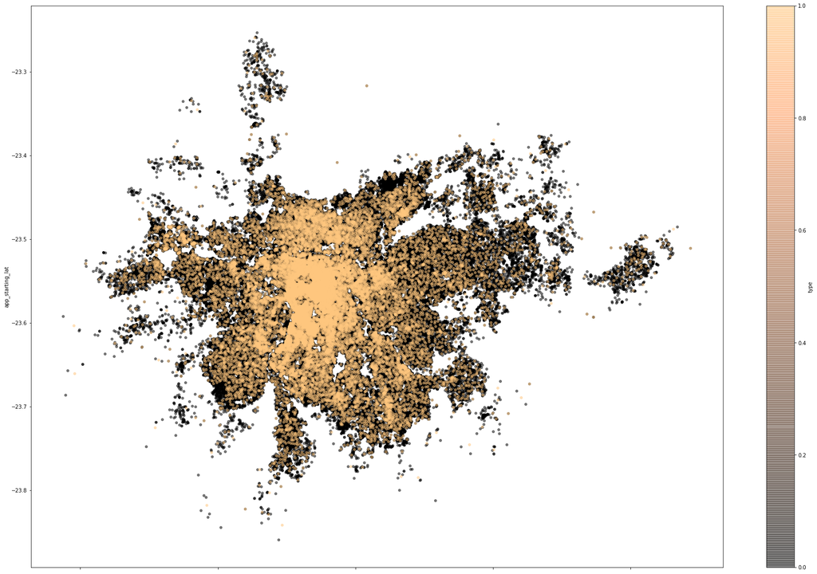

```python
find.plotSites(periods[-1],siteList=True)
```

Fewer golden points are necessary to cover the black shape, this is aligned to a strategy for meeting demand where the number of scooters will hardly be greater or equal to the number of potential customers.